# ML Undocu imputation method

Mario Arce Acosta

2025-03-02

## Variable / data dictionary

- epppnum: Person number. This field differentiates persons within the sample unit. Person number is unique within the sample unit.
- eenlevel: Education level
- eeducate: Highest Degree received or grade completed. What is the highest level of school … has completed or the highest degree … has received?
- evocat: Attended vocational, technical, trade, or business school. Has … ever attended a vocational, technical, trade, or business school beyond high school?
- rhpov: Poverty threshold for this household in this month. Poverty threshold for this household in this month. Official poverty rates (from the CPS) use families not households as the unit of analysis.
- thearn: Total household earned income Reaggregated total household earned income for relevant month of the reference period after topcoding
- tbyear: Year of birth
- rhcalyr: Calendar year for this reference month
- ebmnth: Month of birth
- tage: Age as of last birthday. Edited and imputed age as of last birthday. Topcoding combines persons into last two single year of age groups. User should combine last two age groups for microdata analysis.
- tbrstate: State or country of birth BRSTATE/BCNTRY Where was … born?
- esex: Sex of this person
- epayhr1: Paid by the hour. Does … have a set annual salary, was …paid by the hour or was … paid some other way?
- eslryb1: Salary draw from business. Did … draw a regular salary from this business? (That is, take a regular paycheck, as opposed to just treating the profits as …’s income.)
- tpmsum1: Earnings from job received in this month. What was …’s gross pay before deductions in this month?
- tpmsum2: Earnings from job received in this month. What was …’s gross pay before deductions in this month?
- tjbocc1: Occupation code
- tjbocc2: Occupation code
- eclwrk1: Class of worker
- eclwrk2: Class of worker
- ejbind1: Industry code
- eunion1: Union/employee-association membership. On this job is … a member of either a labor union or an employee association like a union?
- ecntrc1: Coverage by union or something like a union contract
- eocctim1: eocctim1Length of time in this occupation. Considering …’s entire working life, how many years has … been in this occupation or line of work?
- eenrlm: Enrollment status in this month. Was … enrolled in school in this month?
- easst06: Grant, Scholarship, or Tuition remission from school. Did … receive a grant, scholarship, or tuition remission from the school attended?
- ems: Marital status
- epnspous: Person number of spouse
- espeak: Speak language other than English. Does … speak a language other than English at home?
- tlang1: What language is spoken at home. What is this language? (Speaks language other than English at home)
- ehowwell: Ability to speak English. How well does … speak English? (Speaks language other than English at home)
- rcutyp57: Medicaid coverage flag
- rcutyp58: Health ins coverage flag (not Medicare or Medicaid)
- rcuown57: Person number of the owner of the SS coverage
- ecitizen: US Citizenship Status of Respondent. Is … a citizen of the United States?
- enatcit: How the respondent became a US citizen. How is … a U.S. citizen?
- timstat: Immigration status upon entry to the U.S. IMSTAT When … moved to the U.S. to live, what was …’s immigration status?
- eadjust: Whether status has changed to permanent resident ADJUST Has …’s status been changed to permanent resident?
- tadyear: Year status changed to permanent resident ADYEAR What year was …’s status changed to permanent resident?
- tmoveus: Year moved to the United States MOVEUS When did … move to the United States?
- rfnkids: Total number of children under 18 in family. This is family level information placed on the record of each person in the family.
- rmesr: Employment status recode for month
- erace: The race(s) the respondent is. What race(s) does … consider herself/himself to be? 1 White 2 Black or African American 3 American Indian or Alaska Native 4 Asian 5 Native Hawaiian or Other Pacific Islander
- eorigin: Spanish, Hispanic or Latino. Is … Spanish, Hispanic or Latino?
- ebornus: Respondent was born in the U.S.. Is … born in the United States?
- ehhnumpp: Total number of persons in this household in this month
- eafnow: Current Armed Forces status. Is … now on active duty?
- eafever: Lifetime Armed Forces status. Did … ever serve on active duty in the U.S. Armed Forces?
- rcutyp01: Social Security coverage flag
- rcutyp03: Federal SSI coverage flag

```r
library(readr)
SIPP_2008_Wave_2 <- read_csv("C:/Users/mario/Documents/Undocu_Mismatch_Wage_Research_2024 Data/Core_TM SIPP 2008 Wave 2.csv")
View(SIPP_2008_Wave_2)

summary(SIPP_2008_Wave_2)
```

```
##     ssuid              rhcalyr        shhadid         ehhnumpp
##  Length:392702      Min.   :2008   Min.   :11.00   Min.   : 1.000
##  Class :character   1st Qu.:2008   1st Qu.:11.00   1st Qu.: 2.000
##  Mode  :character   Median :2008   Median :11.00   Median : 3.000
##                     Mean   :2008   Mean   :11.25   Mean   : 3.402
##                     3rd Qu.:2009   3rd Qu.:11.00   3rd Qu.: 4.000
##                     Max.   :2009   Max.   :23.00   Max.   :22.000
##      thearn           rhpov         rfnkids         eentaid
##  Min.   :-46667   Min.   : 840   Min.   : 0.000   Length:392702
##  1st Qu.:  1000   1st Qu.:1178   1st Qu.: 0.000   Class :character
##  Median :  3591   Median :1424   Median : 1.000   Mode  :character
##  Mean   :  5008   Mean   :1604   Mean   : 1.136
##  3rd Qu.:  7033   3rd Qu.:1855   3rd Qu.: 2.000
##  Max.   : 98083   Max.   :4056   Max.   :12.000
##    epppnum              ebmnth           tbyear         esex
##  Length:392702      Min.   : 1.000   Min.   :1924   Length:392702
##  Class :character   1st Qu.: 4.000   1st Qu.:1953   Class :character
##  Mode  :character   Median : 7.000   Median :1971   Mode  :character
##                     Mean   : 6.541   Mean   :1971
##                     3rd Qu.:10.000   3rd Qu.:1991
##                     Max.   :12.000   Max.   :2009
##     erace             eorigin            ebornus            ecitizen
##  Length:392702      Length:392702      Length:392702      Length:392702
##  Class :character   Class :character   Class :character   Class :character
##  Mode  :character   Mode  :character   Mode  :character   Mode  :character
##
##
##
##    enatcit             espeak             tlang1            ehowwell
##  Length:392702      Length:392702      Length:392702      Length:392702
##  Class :character   Class :character   Class :character   Class :character
##  Mode  :character   Mode  :character   Mode  :character   Mode  :character
##
##
##
##     eafnow            eafever              tage               ems
##  Length:392702      Length:392702      Length:392702      Length:392702
##  Class :character   Class :character   Class :character   Class :character
##  Mode  :character   Mode  :character   Mode  :character   Mode  :character
##
```

[output cut: 43 more lines]

```
##
##    eadvncfd           ebachfld            egedtm            tbrstate
##  Length:392702      Length:392702      Length:392702      Length:392702
##  Class :character   Class :character   Class :character   Class :character
##  Mode  :character   Mode  :character   Mode  :character   Mode  :character
##
##
##
##    timstat            eadjust            tadyear            tmoveus
##  Length:392702      Length:392702      Length:392702      Length:392702
##  Class :character   Class :character   Class :character   Class :character
##  Mode  :character   Mode  :character   Mode  :character   Mode  :character
##
##
##
```

```r
#Include 1986 amnesty filter
library(dplyr)
sipp08_2 <- SIPP_2008_Wave_2 %>%
  mutate(
    undocu_entry = as.factor(ifelse(timstat=="Other", 1, 0)),
    undocu_likely = as.factor(ifelse(timstat=="Other" & eadjust=="No", 1, 0)),
    education = case_when(
      #Create yrsed variable too, use instead (Duplicate Stata indicators)
      eeducate == "10th Grade"  | eeducate == "11th Grade" | eeducate == "12th grade, no diploma" | eeducate == "1st, 2nd, 3rd, or 4th grade" | eeducate == "5th Or 6th Grade" | eeducate == "7th Or 8th Grade" | eeducate == "9th Grade" | eeducate == "Less Than 1st Grade"~ "No HS diploma",
      eeducate == "Diploma or certificate from a" | eeducate == "High School Graduate - (diploma" ~ "HS diploma",
      eeducate == "Some college, but no degree" ~ "Some college",
      eeducate =="Associate (2-yr) college degree" ~ "Associate's",
      eeducate == "Bachelor's degree (for example:" ~ "Bachelor's",
      eeducate == "Master's degree (For example: MA," ~ "Master's",
      eeducate == "Doctorate degree (for example:" ~ "PhD",
      TRUE ~ "Unknown" # Default case
    ),
    yrsed = case_when(
      eeducate == "10th Grade"~10,
      eeducate == "11th Grade"~11,
      eeducate == "12th grade, no diploma" | eeducate == "Diploma or certificate from a" | eeducate == "High School Graduate - (diploma" | eeducate == "Some college, but no degree" ~12,
      eeducate == "1st, 2nd, 3rd, or 4th grade"~2.5,
      eeducate == "5th Or 6th Grade"~5.5,
      eeducate == "7th Or 8th Grade"~7.5,
      eeducate == "9th Grade"~9,
      eeducate == "Less Than 1st Grade"~0,
      eeducate =="Associate (2-yr) college degree"~14,
      eeducate == "Bachelor's degree (for example:"~16,
      eeducate == "Master's degree (For example: MA,"~17.5,
      eeducate == "Doctorate degree (for example:"~22,
      eeducate == "Professional School degree (for"~16,
      TRUE ~ NA
    ),
    college = as.factor(ifelse(eeducate=="Bachelor's degree (for example:" | eeducate=="Master's degree (For example: MA," | eeducate=="Doctorate degree (for example:", 1, 0)),
    hs_only = as.factor(ifelse(eeducate=="Some college, but no degree" | eeducate== "Associate (2-yr) college degree" | eeducate=="High School Graduate - (diploma" | eeducate=="Diploma or certificate from a", 1, 0)),
    immig_yr = case_when(
      tmoveus == "1961"~1961,
      tmoveus == "1961-1968"~1966,
      tmoveus == "1969-1973"~1971,
      tmoveus == "1974-1978"~1976,
      tmoveus == "1979-1980"~1980,
      tmoveus == "1981-1983"~1982,
      tmoveus == "1984-1985"~1984,
      tmoveus == "1986-1988"~1987,
      tmoveus == "1989-1990"~1989,
      tmoveus == "1991-1992"~1991,
      tmoveus == "1993-1994"~1993,
      tmoveus == "1995-1996"~1995,
      tmoveus == "1997-1998"~1998,
      tmoveus == "1999"~1999,
      tmoveus == "2000"~2000,
      tmoveus == "2001"~2001,
      tmoveus == "2002-2003"~2002,
      tmoveus == "2004"~2004,
      tmoveus == "2005"~2005,
      tmoveus == "2006"~2006,
      tmoveus == "2007"~2007,
      tmoveus == "2008-2009"~2009,
      TRUE ~ 0 # Default case
    ),
    married = as.factor(ifelse(ems=="Married, spouse absent" | ems=="Married, spouse present", 1, 0)),
    english_difficult = as.factor(ifelse(ehowwell=="Not at all" | ehowwell=="Not well", 1, 0)),
    english_home = as.factor(ifelse(tlang1=="Not in Universe", 1, 0)),
    spanish_hispanic_latino = as.factor(ifelse(eorigin=="Yes", 1, 0)),
    medicaid = as.factor(ifelse(rcutyp57=="Yes, covered", 1, 0)),
    household_size = ehhnumpp,
    race = case_when(
      erace=="Asian alone" ~ "Asian",
      erace=="Black alone" ~ "Black",
      erace=="White alone" ~ "White",
      erace=="Residual" ~ "Other",
      TRUE ~ "Unknown"
    ),
    asian = as.factor(ifelse(erace=="Asian alone", 1, 0)),
    black = as.factor(ifelse(erace=="Black alone", 1, 0)),
    white = as.factor(ifelse(erace=="White alone", 1, 0)),
    other_race = as.factor(ifelse(erace=="Residual", 1, 0)),
    employed = as.factor(ifelse(rmesr=="With a job at least 1 but not all" | rmesr=="With a job entire month, absent" | rmesr=="With a job entire month, worked", 1, 0)),
    years_us = rhcalyr - immig_yr,
    citizen = as.factor(ifelse(ecitizen=="Yes", 1, 0)),
    poverty = as.factor(ifelse(thearn<rhpov, 1, 0)),
    armed_forces = as.factor(ifelse(eafnow=="Yes" | eafever=="Yes", 1, 0)),
    health_ins= as.factor(ifelse(rcutyp57=="Yes, covered" | rcutyp58=="Yes, covered" , 1, 0)),
    social_security = as.factor(ifelse(rcutyp01=="Yes, covered" | rcutyp03=="Yes, covered", 1, 0)),
    bpl_mex = as.factor(ifelse(tbrstate=="Central America" & eorigin=="Yes", 1, 0)),
    bpl_usa = as.factor(ifelse(ebornus=="Yes", 1, 0)),
    bpl_asia = as.factor(ifelse(tbrstate == "Eastern Asia"| tbrstate == "South Central Asia"| tbrstate == "South East Asia, West Asia,", 1, 0))
  )

sipp08_2$undocu_likely <- replace(sipp08_2$undocu_likely, sipp08_2$immig_yr <= 1961, 0)
sipp08_2$years_us <- ifelse(sipp08_2$years_us == 2008 | sipp08_2$years_us == 2009 | sipp08_2$years_us == -1 , NA, sipp08_2$years_us)
sipp08_2$tage <- replace(sipp08_2$tage, sipp08_2$tage == "Less than 1 full year old", 0)
sipp08_2$age <- as.numeric(sipp08_2$tage)
sipp08_2$undocu_likely <- replace(sipp08_2$undocu_likely, sipp08_2$armed_forces==1 | sipp08_2$health_ins==1 | sipp08_2$social_security==1, 0 )
sipp08_2$undocu_logical <- as.factor(ifelse(sipp08_2$citizen==0 & (sipp08_2$armed_forces==0 | sipp08_2$health_ins==0 | sipp08_2$social_security==0), 1, 0))


sipp08_2_logistic <- sipp08_2[sipp08_2$citizen == 0, c("undocu_likely", "undocu_logical", "bpl_mex", "bpl_asia", "age", "college", "hs_only", "married", "english_difficult", "spanish_hispanic_latino", "medicaid", "household_size", "poverty", "asian", "black", "white", "other_race", "employed", "years_us","yrsed")]
sipp08_2_knn <- sipp08_2[sipp08_2$citizen == 0, c("undocu_likely", "bpl_mex", "bpl_asia", "age", "college", "hs_only", "married", "english_difficult", "spanish_hispanic_latino", "medicaid", "household_size", "poverty", "asian", "black", "white", "other_race", "employed", "years_us","yrsed")]
sipp08_2_rf <- sipp08_2[sipp08_2$citizen == 0, c("undocu_likely", "bpl_mex", "bpl_asia", "age", "college", "hs_only", "married", "english_difficult", "spanish_hispanic_latino", "medicaid", "household_size", "poverty", "asian", "black", "white", "other_race", "employed", "years_us","yrsed")]
sipp08_2_knn[2:17] <- sapply(sipp08_2_knn[2:17],as.numeric)
sipp08_2_knn <- na.omit(sipp08_2_knn)

View(sipp08_2)
```

age + college + hs_only + married + english_difficult + spanish_hispanic_latino + medicaid + household_size + poverty + race + employed + citizen + years_us

```r
library(caret)
set.seed(0)  # For reproducibility
train_index <- createDataPartition(sipp08_2_logistic$undocu_likely, p = 0.7, list = FALSE)
train_data <- sipp08_2[train_index, ]
test_data <- sipp08_2[-train_index, ]


##Add output to Overleaf (stargazer?; College degree vs No College degree)
logistic_model <- glm(undocu_likely ~ age + college + hs_only + married + english_difficult + spanish_hispanic_latino + bpl_mex + bpl_asia + medicaid + household_size + poverty + asian + black + white + other_race + employed + years_us + yrsed, data = train_data, family = binomial)


summary(logistic_model)
```

```
##
## Call:
## glm(formula = undocu_likely ~ age + college + hs_only + married +
##     english_difficult + spanish_hispanic_latino + bpl_mex + bpl_asia +
##     medicaid + household_size + poverty + asian + black + white +
##     other_race + employed + years_us + yrsed, family = binomial,
##     data = train_data)
##
## Coefficients: (1 not defined because of singularities)
##                           Estimate Std. Error z value Pr(>|z|)
## (Intercept)                3.06739    1.09396   2.804  0.00505 **
## age                       -0.07629    0.01169  -6.525 6.80e-11 ***
## college1                   0.41335    0.78375   0.527  0.59791
## hs_only1                  -0.41933    0.42836  -0.979  0.32761
## married1                   0.32027    0.26434   1.212  0.22567
## english_difficult1         0.40594    0.28106   1.444  0.14864
## spanish_hispanic_latino1   0.49631    0.45725   1.085  0.27773
## bpl_mex1                   0.98328    0.42300   2.325  0.02010 *
## bpl_asia1                  0.20725    0.68103   0.304  0.76089
## medicaid1                -17.76064  727.89154  -0.024  0.98053
## household_size            -0.03359    0.08061  -0.417  0.67688
## poverty1                   1.54763    0.25661   6.031 1.63e-09 ***
## asian1                    -1.58238    0.79068  -2.001  0.04536 *
## black1                    -0.99488    0.64549  -1.541  0.12325
## white1                    -0.82394    0.49804  -1.654  0.09805 .
## other_race1                     NA         NA      NA       NA
## employed1                 -0.22456    0.28027  -0.801  0.42300
## years_us                  -0.05351    0.01730  -3.094  0.00198 **
## yrsed                     -0.18309    0.08255  -2.218  0.02655 *
## ---
## Signif. codes:  0 '***' 0.001 '**' 0.01 '*' 0.05 '.' 0.1 ' ' 1
##
## (Dispersion parameter for binomial family taken to be 1)
##
##     Null deviance: 879.54  on 1644  degrees of freedom
## Residual deviance: 514.84  on 1627  degrees of freedom
##   (15527 observations deleted due to missingness)
## AIC: 550.84
##
## Number of Fisher Scoring iterations: 18
```

```r
sipp08_2_klogistic <- na.omit(sipp08_2_logistic)
levels(sipp08_2_klogistic$undocu_likely) <- make.names(levels(sipp08_2_klogistic$undocu_likely))



set.seed(1)
train_index_klogistic <- createDataPartition(sipp08_2_klogistic$undocu_likely, p = 0.7, list = FALSE)
train_klogistic <- sipp08_2_klogistic[train_index_klogistic, ]
test_klogistic <- sipp08_2_klogistic[-train_index_klogistic, ]

## Create trainControl object
control <- trainControl(
    method = "cv",
    number = 10,
    summaryFunction = twoClassSummary,
    classProbs = TRUE
)
## Train glm with custom trainControl
logistic_kmodel <- train(undocu_likely ~ age + college + hs_only + married + english_difficult + spanish_hispanic_latino + bpl_mex + bpl_asia + medicaid + household_size + poverty + asian + black + white + other_race + employed + years_us + yrsed, train_klogistic,
               method = "glm",
               trControl = control)
p_klogistic <- predict(logistic_kmodel, test_klogistic)

# Generate confusion matrix
klogistic_matrix <- confusionMatrix(p_klogistic, test_klogistic$undocu_likely, positive = "X1")
print(klogistic_matrix)
```

```
## Confusion Matrix and Statistics
##
##           Reference
## Prediction   X0   X1
##         X0 4586  920
##         X1  256  280
##
##                Accuracy : 0.8054
##                  95% CI : (0.7952, 0.8153)
##     No Information Rate : 0.8014
##     P-Value [Acc > NIR] : 0.2247
##
##                   Kappa : 0.2279
##
##  Mcnemar's Test P-Value : <2e-16
##
##             Sensitivity : 0.23333
##             Specificity : 0.94713
##          Pos Pred Value : 0.52239
##          Neg Pred Value : 0.83291
##              Prevalence : 0.19861
##          Detection Rate : 0.04634
##    Detection Prevalence : 0.08871
##       Balanced Accuracy : 0.59023
##
##        'Positive' Class : X1
##
```

```r
library(class)
library(caTools)
set.seed(0)
train_index_knn <- createDataPartition(sipp08_2_knn$undocu_likely, p = 0.7, list = FALSE)
train_knn <- sipp08_2_knn[train_index_knn, ]
test_knn <- sipp08_2_knn[-train_index_knn, ]


# Separate features and labels
View(sipp08_2_knn)
train_scaled <- scale(train_knn[, 2:19])
test_scaled <- scale(test_knn[, 2:19])


knn_model <- knn(
                 train = train_scaled,
                 test = test_scaled,
                 cl = train_knn$undocu_likely,
                 k=1
                 )
```

```r
set.seed(1)
levels(sipp08_2_knn$undocu_likely) <- make.names(levels(sipp08_2_knn$undocu_likely))
train_index_kknn <- createDataPartition(sipp08_2_knn$undocu_likely, p = 0.7, list = FALSE)
train_kknn <- sipp08_2_knn[train_index_kknn, ]
test_kknn <- sipp08_2_knn[-train_index_kknn, ]


# Separate features and labels
View(sipp08_2_knn)
train_kscaled <- scale(train_kknn[, 2:19])
test_kscaled <- scale(test_kknn[, 2:19])


kknn_model <- train(undocu_likely ~., data = train_kknn, method = "knn",
                       trControl = control,
                       tuneLength = 10)
kknn_model
```

```
## k-Nearest Neighbors
##
## 14100 samples
##    18 predictor
##     2 classes: 'X0', 'X1'
##
## No pre-processing
## Resampling: Cross-Validated (10 fold)
## Summary of sample sizes: 12690, 12690, 12690, 12690, 12690, 12690, ...
## Resampling results across tuning parameters:
##
##   k   ROC        Sens       Spec
##    5  0.8982331  0.9299115  0.5292857
##    7  0.8768710  0.9351327  0.4646429
##    9  0.8599374  0.9370796  0.4210714
##   11  0.8471697  0.9381416  0.3725000
##   13  0.8352626  0.9452212  0.3314286
##   15  0.8274583  0.9472566  0.3103571
##   17  0.8209328  0.9515044  0.2892857
##   19  0.8168875  0.9538053  0.2675000
##   21  0.8130898  0.9552212  0.2507143
##   23  0.8104608  0.9569027  0.2414286
##
## ROC was used to select the optimal model using the largest value.
## The final value used for the model was k = 5.
```

```r
predict_kknn <- predict(kknn_model, test_kknn)

kknn_matrix <- confusionMatrix(predict_kknn, test_kknn$undocu_likely, positive = "X1")
print(klogistic_matrix)
```

```
## Confusion Matrix and Statistics
##
##           Reference
## Prediction   X0   X1
##         X0 4586  920
##         X1  256  280
##
##                Accuracy : 0.8054
##                  95% CI : (0.7952, 0.8153)
##     No Information Rate : 0.8014
##     P-Value [Acc > NIR] : 0.2247
##
##                   Kappa : 0.2279
##
##  Mcnemar's Test P-Value : <2e-16
##
##             Sensitivity : 0.23333
##             Specificity : 0.94713
##          Pos Pred Value : 0.52239
##          Neg Pred Value : 0.83291
##              Prevalence : 0.19861
##          Detection Rate : 0.04634
##    Detection Prevalence : 0.08871
##       Balanced Accuracy : 0.59023
##
##        'Positive' Class : X1
##
```

```r
sipp08_2_rf <- na.omit(sipp08_2_rf)
levels(sipp08_2_rf$undocu_likely) <- make.names(levels(sipp08_2_rf$undocu_likely))
library("rpart") ## recursive partitioning

train_index_rf <- createDataPartition(sipp08_2_rf$undocu_likely, p = 0.7, list = FALSE)
train_rf <- sipp08_2_rf[train_index_rf, ]
test_rf <- sipp08_2_rf[-train_index_rf, ]



set.seed(1)
rf_model <- train(undocu_likely ~ age + college + hs_only + married + english_difficult + spanish_hispanic_latino + bpl_mex + bpl_asia + medicaid + household_size + poverty + asian + black + white + other_race + employed + years_us + yrsed,
               data = train_rf,
               method = "ranger",
               trControl = control,
               tuneLength = 5)
print(rf_model)
```

```
## Random Forest
##
## 14100 samples
##    18 predictor
##     2 classes: 'X0', 'X1'
##
## No pre-processing
## Resampling: Cross-Validated (10 fold)
## Summary of sample sizes: 12690, 12690, 12690, 12690, 12690, 12690, ...
## Resampling results across tuning parameters:
##
##   mtry  splitrule   ROC        Sens       Spec
##    2    gini        0.9050880  0.9981416  0.13285714
##    2    extratrees  0.8707135  0.9997345  0.04357143
##    6    gini        0.9872208  0.9878761  0.84464286
##    6    extratrees  0.9772903  0.9868142  0.74857143
##   10    gini        0.9901247  0.9870796  0.88357143
##   10    extratrees  0.9877211  0.9860177  0.87571429
##   14    gini        0.9898908  0.9854867  0.88642857
##   14    extratrees  0.9885473  0.9853097  0.89071429
##   18    gini        0.9889765  0.9846018  0.88750000
##   18    extratrees  0.9884648  0.9845133  0.89285714
##
## Tuning parameter 'min.node.size' was held constant at a value of 1
## ROC was used to select the optimal model using the largest value.
## The final values used for the model were mtry = 10, splitrule = gini
##  and min.node.size = 1.
```

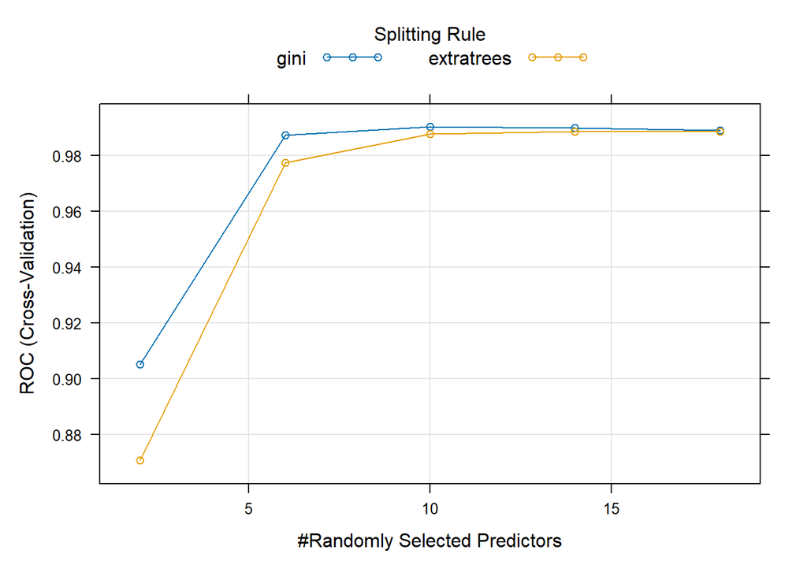

```r
plot(rf_model)
```

```r
p_rf <- predict(rf_model, test_rf)
rf_matrix <- confusionMatrix(p_rf, test_rf$undocu_likely, positive="X1")
rf_matrix
```

```
## Confusion Matrix and Statistics
##
##           Reference
## Prediction   X0   X1
##         X0 4770  107
##         X1   72 1093
##
##                Accuracy : 0.9704
##                  95% CI : (0.9658, 0.9745)
##     No Information Rate : 0.8014
##     P-Value [Acc > NIR] : < 2e-16
##
##                   Kappa : 0.9059
##
##  Mcnemar's Test P-Value : 0.01104
##
##             Sensitivity : 0.9108
##             Specificity : 0.9851
##          Pos Pred Value : 0.9382
##          Neg Pred Value : 0.9781
##              Prevalence : 0.1986
##          Detection Rate : 0.1809
##    Detection Prevalence : 0.1928
##       Balanced Accuracy : 0.9480
##
##        'Positive' Class : X1
##
```

```r
library(pROC)
library(xtable)
```

```r
##Logistic Classification model
# Predict probabilities
predictions <- predict(logistic_model, newdata = test_data, type = "response")
#colAUC(predictions, test_data[["Class"]], plotROC = TRUE)

# Convert probabilities to binary outcome (threshold = 0.5)
pred_classes <- ifelse(predictions > 0.5, 1, 0)

# Convert to factor for evaluation
pred_classes <- as.factor(pred_classes)

logistic_matrix <- confusionMatrix(pred_classes, test_data$undocu_likely, positive = "1")
logistic_matrix
```

```
## Confusion Matrix and Statistics
##
##           Reference
## Prediction     0     1
##          0 33789  2772
##          1  1672  1104
##
##                Accuracy : 0.887
##                  95% CI : (0.8839, 0.8901)
##     No Information Rate : 0.9015
##     P-Value [Acc > NIR] : 1
##
##                   Kappa : 0.2721
##
##  Mcnemar's Test P-Value : <2e-16
##
##             Sensitivity : 0.28483
##             Specificity : 0.95285
##          Pos Pred Value : 0.39769
##          Neg Pred Value : 0.92418
##              Prevalence : 0.09853
##          Detection Rate : 0.02807
##    Detection Prevalence : 0.07057
##       Balanced Accuracy : 0.61884
##
##        'Positive' Class : 1
##
```

```r
knn_matrix <- confusionMatrix(test_knn$undocu_likely, knn_model)
knn_matrix
```

```
## Confusion Matrix and Statistics
##
##           Reference
## Prediction    0    1
##          0 4724  118
##          1  108 1092
##
##                Accuracy : 0.9626
##                  95% CI : (0.9575, 0.9672)
##     No Information Rate : 0.7997
##     P-Value [Acc > NIR] : <2e-16
##
##                   Kappa : 0.8829
##
##  Mcnemar's Test P-Value : 0.5494
##
##             Sensitivity : 0.9776
##             Specificity : 0.9025
##          Pos Pred Value : 0.9756
##          Neg Pred Value : 0.9100
##              Prevalence : 0.7997
##          Detection Rate : 0.7819
##    Detection Prevalence : 0.8014
##       Balanced Accuracy : 0.9401
##
##        'Positive' Class : 0
##
```

```r
## Logical edits accuracy sipp08_2$undocu_logical
FN_logical <- length(which(sipp08_2_logistic$undocu_logical==0 & sipp08_2_logistic$undocu_likely==1))
TN_logical <- length(which(sipp08_2_logistic$undocu_logical==0 & sipp08_2_logistic$undocu_likely==0))
FP_logical <- length(which(sipp08_2_logistic$undocu_logical==1 & sipp08_2_logistic$undocu_likely==0))
TP_logical <- length(which(sipp08_2_logistic$undocu_logical==1 & sipp08_2_logistic$undocu_likely==1))

specificty_logical<- TN_logical/(TN_logical+FP_logical)
sensitivity_logical<- TP_logical/(TP_logical+FN_logical)
ppv_logical <- TP_logical/(TP_logical+FP_logical)
accuracy_logical <- (TP_logical+TN_logical)/(TP_logical+TN_logical+FP_logical+FN_logical)


## Model comparison table creation
# ML statistics
accuracy <- c(accuracy_logical, logistic_matrix$overall[['Accuracy']], klogistic_matrix$overall[['Accuracy']], knn_matrix$overall[['Accuracy']], kknn_matrix$overall[['Accuracy']], rf_matrix$overall[['Accuracy']])

sensitivity <- c(sensitivity_logical, logistic_matrix$byClass[['Sensitivity']], klogistic_matrix$byClass[['Sensitivity']], knn_matrix$byClass[['Sensitivity']], kknn_matrix$byClass[['Sensitivity']], rf_matrix$byClass[['Sensitivity']])

specificity <- c(specificty_logical, logistic_matrix$byClass[['Specificity']], klogistic_matrix$byClass[['Specificity']], knn_matrix$byClass[['Specificity']], kknn_matrix$byClass[['Specificity']], rf_matrix$byClass[['Specificity']])

ppv <- c(ppv_logical, logistic_matrix$byClass[['Pos Pred Value']], klogistic_matrix$byClass[['Pos Pred Value']], knn_matrix$byClass[['Pos Pred Value']], kknn_matrix$byClass[['Pos Pred Value']], rf_matrix$byClass[['Pos Pred Value']])


ml_table <- data.frame(sensitivity, specificity, ppv, accuracy)
ml_comparison <- as.data.frame(t(ml_table))
colnames(ml_comparison) <- c("Logical edits", "Logistic Classification", "K-folds Logistic", "KNN Classifier", "K-folds KNN", "RF")

# ML metrics (comparison of ML models)
xtable(ml_comparison, digits=4)
```

```
## % latex table generated in R 4.4.1 by xtable 1.8-4 package
## % Thu Mar 13 01:17:15 2025
## \begin{table}[ht]
## \centering
## \begin{tabular}{rrrrrrr}
##   \hline
##  & Logical edits & Logistic Classification & K-folds Logistic & KNN Classifier & K-folds KNN & RF \\
##   \hline
## sensitivity & 1.0000 & 0.2848 & 0.2333 & 0.9776 & 0.5608 & 0.9108 \\
##   specificity & 0.0004 & 0.9528 & 0.9471 & 0.9025 & 0.9337 & 0.9851 \\
##   ppv & 0.1842 & 0.3977 & 0.5224 & 0.9756 & 0.6771 & 0.9382 \\
##   accuracy & 0.1845 & 0.8870 & 0.8054 & 0.9626 & 0.8596 & 0.9704 \\
##    \hline
## \end{tabular}
## \end{table}
```

```r
print(ml_comparison)
```

```
##             Logical edits Logistic Classification K-folds Logistic
## sensitivity  1.0000000000               0.2848297        0.2333333
## specificity  0.0003997202               0.9528496        0.9471293
## ppv          0.1841944297               0.3976945        0.5223881
## accuracy     0.1844604786               0.8870275        0.8053625
##             KNN Classifier K-folds KNN        RF
## sensitivity      0.9776490   0.5608333 0.9108333
## specificity      0.9024793   0.9337051 0.9851301
## ppv              0.9756299   0.6770624 0.9381974
## accuracy         0.9625952   0.8596491 0.9703740
```

```r
k_kvalues <- c(1, 3, 5, 7, 15, 19)

# Calculate accuracy for each k value
accuracy_kvalues <- sapply(k_kvalues, function(k) {
  k_kknn_model <- knn(
                 train = train_kscaled,
                 test = test_kscaled,
                 cl = train_kknn$undocu_likely,
                 k=k
                 )
  1 - mean(k_kknn_model != train_kknn$undocu_likely)
})
```

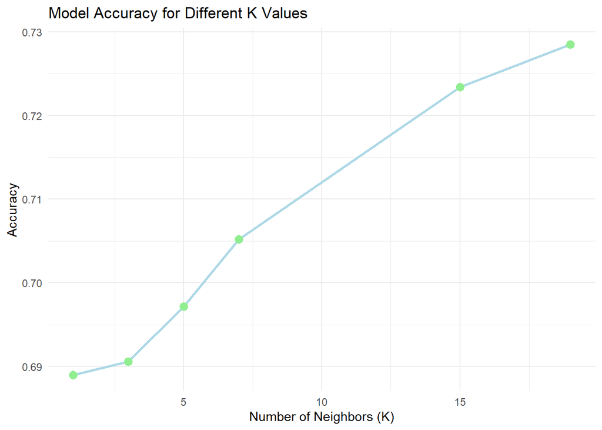

```r
# Create a data frame for plotting
accuracy_kdata <- data.frame(K = k_kvalues, Accuracy = accuracy_kvalues)

# Plotting
ggplot(accuracy_kdata, aes(x = K, y = Accuracy)) +
  geom_line(color = "lightblue", linewidth = 1) +
  geom_point(color = "lightgreen", size = 3) +
  labs(title = "Model Accuracy for Different K Values",
       x = "Number of Neighbors (K)",
       y = "Accuracy") +
  theme_minimal()
```

```r
k_values <- c(1, 3, 5, 7, 15, 19)

# Calculate accuracy for each k value
accuracy_values <- sapply(k_values, function(k) {
  k_knn_model <- knn(
                 train = train_scaled,
                 test = test_scaled,
                 cl = train_knn$undocu_likely,
                 k=k
                 )
  1 - mean(k_knn_model != train_knn$undocu_likely)
})
```

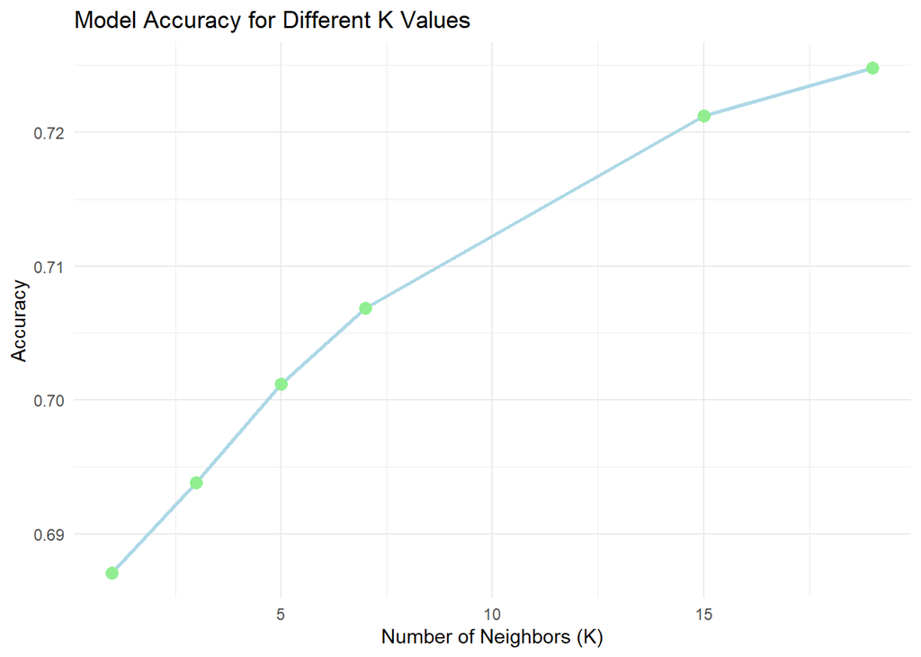

```r
# Create a data frame for plotting
accuracy_data <- data.frame(K = k_values, Accuracy = accuracy_values)

# Plotting
ggplot(accuracy_data, aes(x = K, y = Accuracy)) +
  geom_line(color = "lightblue", linewidth = 1) +
  geom_point(color = "lightgreen", size = 3) +
  labs(title = "Model Accuracy for Different K Values",
       x = "Number of Neighbors (K)",
       y = "Accuracy") +
  theme_minimal()
```

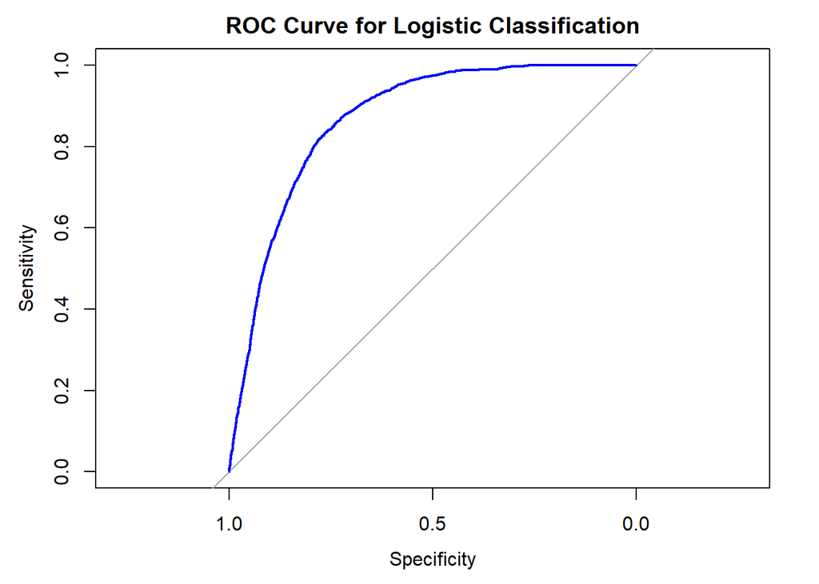

```r
pp_klogistic <- predict(logistic_kmodel, test_klogistic, type="prob")[,2]
# Generate ROC curve
logistic_roc <- roc(test_data$undocu_likely, predictions)
klogistic_roc <- roc(test_klogistic$undocu_likely, pp_klogistic)
# Plot the ROC curve
plot(logistic_roc, col = "blue", main = "ROC Curve for Logistic Classification")
```

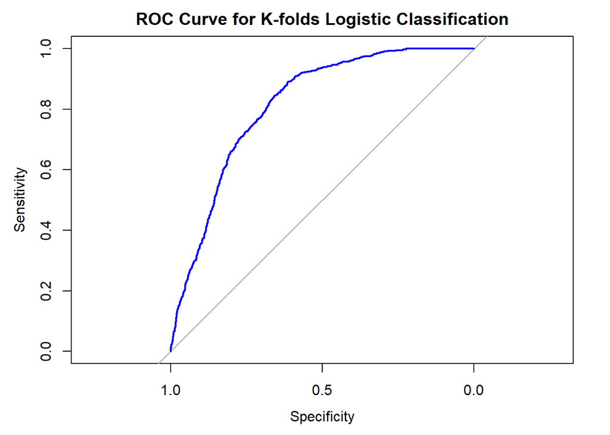

```r
plot(klogistic_roc, col = "blue", main = "ROC Curve for K-folds Logistic Classification")
```

```r
# Compute AUC
logistic_auc <- auc(logistic_roc)
print(paste("AUC:", round(logistic_auc, 3)))
```

```
## [1] "AUC: 0.867"
```

```r
klogistic_auc <- auc(klogistic_roc)
print(paste("AUC:", round(klogistic_auc, 3)))
```

```
## [1] "AUC: 0.813"
```